# Lab 6.1 - Visualizing Spatial Data

Sherise Immanuela

Fall 2022

The late comedian [Mitch Hedberg](https://en.wikipedia.org/wiki/Mitch_Hedberg) famously joked that “La Quinta” is Spanish for “next to Denny’s”. In this lab exercise, we explore the accuracy of his claim that [Denny’s](https://www.dennys.com/), a casual diner chain that is open 24 hours, is actually co-located with [La Quinta Inn and Suites](http://www.lq.com/), a hotel chain. This lab is inspired by a blog post by John Reiser entitled [Mitch Hedberg and GIS](http://njgeo.org/2014/01/30/mitch-hedberg-and-gis/).

## Loading the Dataset

We use three datasets, all stored in [./data](https://cs.calvin.edu/courses/info/601/06wrangling/lab/data/.):

- `dennys` — The locations of all Denny’s restaurants:
  - *Scraped* from [All Denny’s Locations](https://locations.dennys.com/)
  - Described here: [Locations of Denny’s restaurants](https://rstudio-education.github.io/dsbox/reference/dennys.html)
- `laquinta` — The locations of all La Quinta hotels:
  - *Scraped* from [La Quinta Locations](https://www.wyndhamhotels.com/laquinta/locations)
  - Described here: [Locations of La Quinta Inn motels](https://rstudio-education.github.io/dsbox/reference/laquinta.html)
- `states` — The names of all the US states, including DC, plus some additional information.

```r
dennys <- read_rds("data/dennys.rds")
laquinta <- read_rds("data/laquinta.rds")
states <- read_csv("data/states.csv", col_types = cols(
  name = col_character(),
  abbreviation = col_character(),
  area = col_double()
))
```

Data Dictionary:

dennys (a tibble with 1643 rows and 6 variables) `address`: Street address of the restaurant `city`: City of the restaurant. `state`: US State of the restaurant. `zip`: US ZIP Code of the restaurant. `longitude`: The longitude of the restaurant in degrees. `latitude`: The latitude of the restaurant. in degrees.

laquinta (a tibble with 909 rows and 6 variables) `address`: Street address of the motel. `city`: City of the motel. `state`: US State of the motel. `zip`: US ZIP Code of the motel. `longitude`: The longitude of the motel in degrees. `latitude`: The latitude of the motel in degrees.

states (a tibble with 51 rows and 3 variables) `name`: Name of the state. `abbreviation`: Abbreviation of the state name. `area`: Area of state.

## Focusing on US Locations

We limit our analysis to Denny”s and La Quinta locations in the United States.

```r
dennys %>%
  filter(!(state %in% states$abbreviation))
```

```
# A tibble: 0 × 6
# … with 6 variables: address <chr>, city <chr>, state <chr>, zip <chr>,
#   longitude <dbl>, latitude <dbl>
```

There are no Denny’s locations outside the US.

```r
laquinta <- laquinta %>%
  filter((state %in% states$abbreviation))
```

There are 14 La Quinta records that were filtered out because they’re not in the US.

## Computing Frequencies

We now compute some density statistics for the two franchises.

### By State

```r
dennysCount <- dennys %>%
  group_by(state) %>%
  count(state, sort=TRUE)
dennysCount
```

```
# A tibble: 51 × 2
# Groups:   state [51]
   state     n
   <chr> <int>
 1 CA      403
 2 TX      200
 3 FL      140
 4 AZ       83
 5 IL       56
 6 NY       56
 7 WA       49
 8 OH       44
 9 MO       42
10 PA       40
# … with 41 more rows
```

California has the most Denny’s locations (403), while Delaware has the least (1).

```r
laquintaCount <- laquinta %>%
  group_by(state) %>%
  count(state, sort=TRUE)
laquintaCount
```

```
# A tibble: 48 × 2
# Groups:   state [48]
   state     n
   <chr> <int>
 1 TX      237
 2 FL       74
 3 CA       56
 4 GA       41
 5 TN       30
 6 OK       29
 7 LA       28
 8 CO       27
 9 NM       19
10 NY       19
# … with 38 more rows
```

Texas has the most La Quinta locations (237), while Maine has the least (1).

### By Area

```r
dennysArea <- left_join(dennysCount, states, by = c("state" = "abbreviation"))

dennysDensity <- dennysArea %>%
  mutate(density = (n/area)*1000) %>%
  arrange(desc(density))
dennysDensity
```

```
# A tibble: 51 × 5
# Groups:   state [51]
   state     n name                     area density
   <chr> <int> <chr>                   <dbl>   <dbl>
 1 DC        2 District of Columbia     68.3  29.3
 2 RI        5 Rhode Island           1545.    3.24
 3 CA      403 California           163695.    2.46
 4 CT       12 Connecticut            5543.    2.16
 5 FL      140 Florida               65758.    2.13
 6 MD       26 Maryland              12406.    2.10
 7 NJ       10 New Jersey             8723.    1.15
 8 NY       56 New York              54555.    1.03
 9 IN       37 Indiana               36420.    1.02
10 OH       44 Ohio                  44826.    0.982
# … with 41 more rows
```

The District of Columbia has the highest density by far, but mainly because the area is so small. It’s interesting that Texas does not have a high density, especially because it’s the state with the 2nd highest number of Denny’s.

```r
laquintaArea <- left_join(laquintaCount, states, by = c("state" = "abbreviation"))

laquintaDensity <- laquintaArea %>%
  mutate(density = (n/area)*1000) %>%
  arrange(desc(density))
laquintaDensity
```

```
# A tibble: 48 × 5
# Groups:   state [48]
   state     n name             area density
   <chr> <int> <chr>           <dbl>   <dbl>
 1 RI        2 Rhode Island    1545.   1.29
 2 FL       74 Florida        65758.   1.13
 3 CT        6 Connecticut     5543.   1.08
 4 MD       13 Maryland       12406.   1.05
 5 TX      237 Texas         268596.   0.882
 6 TN       30 Tennessee      42144.   0.712
 7 GA       41 Georgia        59425.   0.690
 8 NJ        5 New Jersey      8723.   0.573
 9 MA        6 Massachusetts  10554.   0.568
10 LA       28 Louisiana      52378.   0.535
# … with 38 more rows
```

## Plotting Locations

Finally, we plot the locations (latitude and longitude) of both establishments.

To do this, we’ll put the two datasets together into a single data frame. First, we’ll add an identifier variable called `establishment` to distinguish rows from the two datasets, and then we’ll bind them with the `bind_rows` function (n.b., this binding works because the two tables have the same columns):

```r
dn_lq <- bind_rows(
  dennys %>% mutate(establishment = "Denny's"),
  laquinta %>% mutate(establishment = "La Quinta"),
)
```

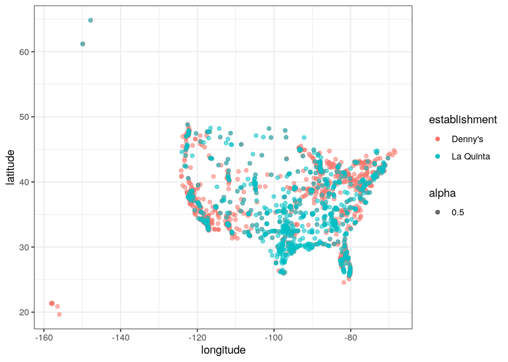

```r
dn_lq %>%
  ggplot() +
  aes(x = longitude, y = latitude, color = establishment, alpha=0.5) +
  geom_point()
```

## Drawing Conclusions

In conclusion, Denny’s restaurants and La Quinta motels appear to be visually co-located. This is especially true for locations in the East Coast and West Coast, and even Midwest.